# DS105-01-09 - Dependent t-Test Activity

Dependent t-tests are used when your samples are related in some way, but you still want to see if the means change. It may be change over time, or change with treatment, etc.  
**Requires:**  
- independent *categorical* variable  
- dependent *continuous* variable

## QUESTION:

Did the mean of `miles per gallon` of hybrid cars change from 2012 to 2013?  
*You will need to test for the assumption of normality for both groups by creating a histogram, and then run a `dependent t-test`.*

## Import Packages

```python
import pandas as pd
from scipy import stats
```

## Load Data

```python
hybrid201213 = pd.read_excel('./assets/hybrid2012-13.xlsx')
```

```python
hybrid201213.head()
```

|  | vehicle | msrp2012 | accelrate2012 | mpg2012 | mpgmpge2012 | carclass2012 | carclass_id2012 | msrp2013 | accelrate2013 | mpg2013 | mpgmpge2013 | carclass2013 | carclass_id2013 |
| --- | --- | --- | --- | --- | --- | --- | --- | --- | --- | --- | --- | --- | --- |
| 0 | ActiveHybrid 3 | 19006.62 | 9.35 | 50 | 50 | C | 1 | 19080 | 8.70 | 50 | 50 | C | 1 |
| 1 | ActiveHybrid 5 | 32095.61 | 8.82 | 50 | 95 | M | 3 | 24995 | 12.66 | 45 | 45 | C | 1 |
| 2 | Ampera | 31739.55 | 11.11 | 37 | 98 | C | 1 | 24200 | 10.20 | 50 | 50 | M | 3 |
| 3 | Camry LE | 62180.23 | 16.67 | 26 | 26 | M | 3 | 18600 | 11.76 | 42 | 42 | C | 1 |
| 4 | Chevrolet Volt | 59126.14 | 16.95 | 31 | 31 | M | 3 | 69850 | 16.39 | 21 | 21 | SUV | 6 |

## Test Assumptions

Create a histogram for each variable.

**`mpg2012` for the miles per gallon (mpg) of 2012 hybrid cars**

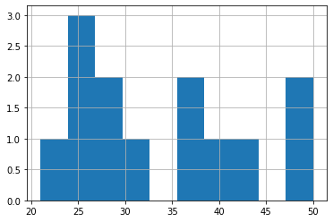

```python
hybrid201213['mpg2012'].hist()
```

**`mpg2013` for the miles per gallon (mpg) of 2013 hybrid cars**

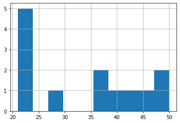

```python
hybrid201213['mpg2013'].hist()
```

## Run the Analysis

You can use the function `stats.ttest_rel()` to compute a dependent t-test in Python.

```python
stats.ttest_rel(hybrid201213['mpg2012'], hybrid201213['mpg2013'])
```

```
Ttest_relResult(statistic=0.14466598084438312, pvalue=0.8873759030512349)
```

- `p` value is the one associated with the `t-test`
- `p` value is *not* significant at **`p > .05.`**

## CONCLUSION:

There is *no significant difference* in hybrid car `mpg` ratings from 2012 to 2013, since the `p` value is not less than .05.